# lab_11

b06208016楊鎧綾

November 23, 2018

## 13.24

### a

step.1 null hypothesis:the pulse rate of men is 72  
alternative hypothesis:the pulse rate of men is not 72  
$H_0:\mu=72$  
$H_a:\mu \neq 72$  
$\mu$ means the pulse rate of men

```r
t_score=(70.42-72)/(9.95/sqrt(57))
```

step.2 the sample size is big enough to continue hypothesis test, the t-score=-1.199

```r
2*pt(t_score,df=56)
```

```
## [1] 0.2356278
```

### b

step.1 null hypothesis:the pulse rate of women is 72  
alternative hypothesis:the pulse rate of women is not 72  
$H_0:\mu=72$  
$H_a:\mu \neq 72$  
$\mu$ means the pulse rate of women

```r
t_score=(76.9-72)/(11.6/sqrt(35))
```

step.2 the sample size is big enough to continue hypothesis test, the t-score=2.499

```r
2*pt(t_score,df=34,lower.tail = F)
```

```
## [1] 0.01744642
```

step.3 the p-value=0.017  
step.4 set alpha=0.05,the p-value is smaller than alpha, so we can reject null hypothesis  
step.5 we can say that the pulse rate of women is not 72

### c

under $\alpha=0.05$  
the result of (a) means that the mean of pulse of men is almost 72  
the result of (b) means that the mean of pulse of women is not 72

## 13.38

### a

```r
bean_d=c(4,4,5,1,-2,0,2,4,-3,0,0,0,-2,2,1)
```

null hypothesis:two hands are the same  
alternative hypothesis:dominant hand has better manual dexterity than nondominant hand  
$H_0:\mu_d=0$  
$H_a:\mu_d>0$  
$\mu_d$ means the difference of beans of dominant hand and nondominant hand place

### b

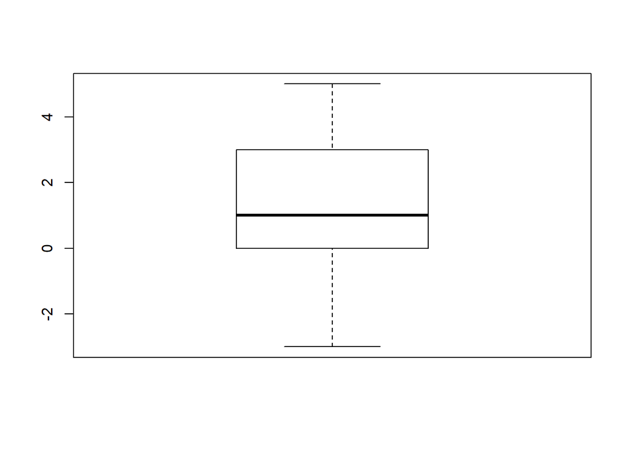

```r
boxplot(bean_d)
```

as the boxplot shows the data has no outliers and no extreme skewed, so we can continue hypothesis test

### c

```r
t.test(bean_d,alternative="greater",paired = F,var.equal = F,conf.level = 0.95)
```

```
##
##  One Sample t-test
##
## data:  bean_d
## t = 1.6974, df = 14, p-value = 0.05587
## alternative hypothesis: true mean is greater than 0
## 95 percent confidence interval:
##  -0.04018838         Inf
## sample estimates:
## mean of x
##  1.066667
```

the p-value is 0.05587 which is larger than $\alpha=0.05$ ,so we cannot reject the null hypothesis test, we can say that two hands are the same

### d

```r
t.test(bean_d,alternative="greater",paired = F,var.equal = F,conf.level = 0.9)
```

```
##
##  One Sample t-test
##
## data:  bean_d
## t = 1.6974, df = 14, p-value = 0.05587
## alternative hypothesis: true mean is greater than 0
## 90 percent confidence interval:
##  0.2214131       Inf
## sample estimates:
## mean of x
##  1.066667
```

the p-value is 0.05587 which is less than $\alpha=0.1$ ,so we can reject the null hypothesis test, we can say that dominant hand has better manual dexterity than nondominant hand

### e

假設我們要證明的是慣用手比較靈敏，因為證明一件事是對的往往比反對困難，所以我們要做的是證明兩隻手是一樣的是錯的，  
而我們根據這個假說去抽樣，看抽樣的平均值的落點來算出如果我們說虛無假設是錯的，但事實上他是對的的機率是多少，  
如果比我們所設定的最大誤差值小，那我們就可以否定虛無假設，而說對立假設是對的，  
也就是說c小題覺得兩隻手無差別，而d小題慣用手比非慣用手好，  
他們的差別是在我們可以接受型一誤差的程度

## 13.58

### a

step.1null hypothesis:the two population of students are equal  
alternative hypothesis:the two population of students are not equal  
$H_0$:p1-p2=0  
$H_a$:p1-p2 $\neq$ 0  
p1-p2 means the difference of proportion of two samples

```r
t_score=(7.66-6.81-0)/sqrt(((1.34^2)/25)+((1.73^2)/148))
```

step.2 the sample is random selected and is big enough or normal distribution，the t-score is 2.80

```r
2*pt(t_score, df =38, lower.tail = FALSE)
```

```
## [1] 0.007954814
```

step.3 the p-value is 0.00795  
step.4 the p-value is smaller than 0.05(we set the significent leve($\alpha$) as 0.05),so it is statically significant evidence to conclude that **null hypothesis is wrong**，we can reject the null value  
step.5 so we can say that the mean number of hours of sleep for the two populations of students are not equal

### b

the two conditions are:  
1.approximately normal(no outlier or extreme skewed)  
2.large random sample(large than 30)  
the data need to meet at least one condition  
non-liberal arts is 148 which is large enough but it has outlier  
liberal arts has small sample size but it is approximately normal  
the unpooled test degree of freedom is 38 which is big enough, so we can use hypothesis test

### c

step.1null hypothesis:the two population of students are equal  
alternative hypothesis:the two population of students are not equal  
$H_0$:p1-p2=0  
$H_a$:p1-p2 $\neq$ 0  
p1-p2 means the difference of proportion of two samples

```r
sp=sqrt((24*(1.34^2)+147*(1.73^2))/(25+148-2))
t_score=(7.66-6.81-0)/(sp*sqrt((1/25)+(1/148)))
t_score
```

```
## [1] 2.338829
```

step.2 the sample is random selected and is big enough or normal distribution，the t-score is 2.34

```r
2*pt(t_score, df =25+148-2, lower.tail = FALSE)
```

```
## [1] 0.02050042
```

step.3 the p-value is 0.02  
step.4 the p-value is smaller than 0.05(we set the significent leve($\alpha$) as 0.05),so it is statically significant evidence to conclude that **null hypothesis is wrong**，we can reject the null value  
step.5 so we can say that the mean number of hours of sleep for the two populations of students are not equal

the unpooled one is better all the time  
but as the text book say, if the large sample has large standard error, it is better to use pooled test

## 13.64

### a

**tne null hypothesis can be rejected** ,because the $\mu$ is not in the confidence level, so can reject the $H_0:\mu=25$

### b

**tne null hypothesis cannot be rejected** ,because the $\mu$ is in the confidence level, so we canotn reject the $H_0:\mu=25$

### c

**tne null hypothesis cannot be rejected** , even though the $\mu$ is in the confidence level, but the $H_a:\mu<25$ ,the confidence interval is (26 to 30) which is above $\mu$ not less than $\mu$, so we canotn reject the $H_0:\mu=25$

## 13.76

### a

**hypothesis test,categorical,one proportion**  
null hypothesis:the probability of borning in October is no difference to other months  
alternative hypothesis:people more likely to born in October  
$H_0$:p=31/365;$H_a$:p > 31/365  
p means the probability of borning in October  
because Max hypothesis something so it is a hypothesis test  
出生月份是類別資料而不是連續資料，而且他只有假設一個比例，所以是one proportion  
phat=22/170

### b

**confidence interval,numerical,paired data**  
因為它是實際抽樣28位病人，得到xbar及standard deviation，目的是推估出信賴區間，所以是confidence level  
n=28,mu_d=23.29,standard error of mu_d is 38.28,so we can calculate t-score and do confidence interval  
cholest 指數是連續資料，而且他是從同一個病人取不同天的cholesterol level，比較兩次取樣的差別，關心的是差別本身而不是母體，所以是paired data

## 13.78

### a

$dhat=t/sqrt(n)$

```r
1.48/sqrt(30)
```

```
## [1] 0.2702098
```

dhat的值比較接近0.2，所以她的effect size magnitude 是small

### b

$dhat=t*sqrt(1/n1+1/n2)$

```r
abs(-2.33*sqrt(1/40+1/50))
```

```
## [1] 0.4942676
```

dhat的值比較接近0.5，所以她的effect size magnitude 是medium